# Свёрточные сети

На семинаре мы ближе познакомимся с основным инструментом для работы с изображениями — **свёрточными сетями (convolutional neural network, CNN)**. Ниже, в качестве примера такой сети, представлена сеть [LeNet-5](http://yann.lecun.com/exdb/publis/pdf/lecun-01a.pdf) для распознавания рукописных знаков.

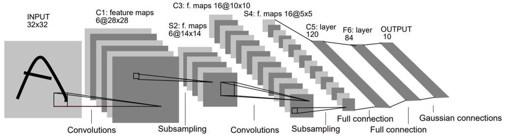

Простейшая архитектура **CNN** для классификации изображений состоит из последовательности чередующихся **свёрточных** и **пулинговых** слоёв (**pooling layer**, **subsamling**), которая завершается **полносвязными слоями (fully connected layer)**, образующими **многослойный перцептрон** (**multilayer perceptron**, **MLP**). **MLP** часто называют "головой" сети.

Функционально, свёрточная часть сети извлекает признаки из изображения, а MLP предсказывает его класс.

**План семинара:**

1. Cвёрточный слой и его параметры
- Пуллинговый слой
- Подготавливаем данные
- Простая архитектура свёрточной сети
- Обучаем сеть
- Визуализируем параметры сети
- Полезные материалы

## Cвёрточный слой и его параметры

В PyTorch свёрточный слой представлен в модуле `nn` функцией [`Conv2d`](https://pytorch.org/docs/stable/generated/torch.nn.Conv2d.html) с параметрами:

- количество входных каналов `in_channels`
- количество выходных каналов `out_channels`
- размер ядра `kernel_size`
- шаг `stride`
- паддинг `padding`
- режим паддинга `padding_mode` (`'zeros'`, `'reflect'` и др.)
- `dilation`

**Размер ядра** - `int`, если ядро квадратное и кортеж из двух чисел, если ядро прямоугольное. Задает размер фильтра, с которым производится свертка изображения.

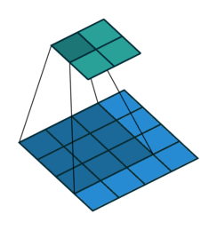

Эта и следующие анимации взяты [здесь](https://github.com/vdumoulin/conv_arithmetic)

**Шаг** - задает шаг, в пикселях, на который сдвигается фильтр. `int`, если по горизонтали и вертикали сдвигается на одно и то же число. Кортеж из двух чисел, если сдвиги разные.

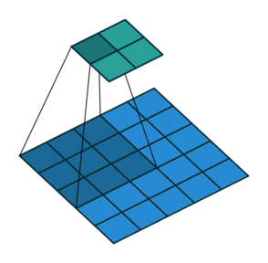

Шаг: 2

**Паддинг** - количество пикселей, которыми дополняется изображение. Аналогично шагу и размеру ядра, может быть, как `int`, так и кортежем из двух чисел.

**Произвольный паддинг**

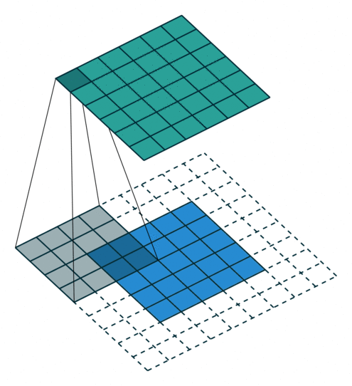

**Half pading**

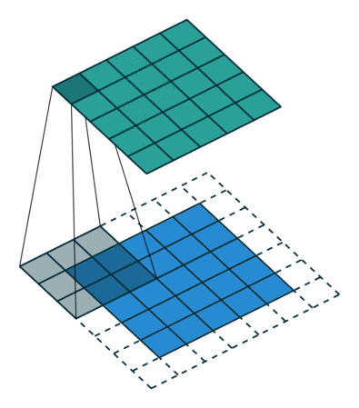

**Full padding**

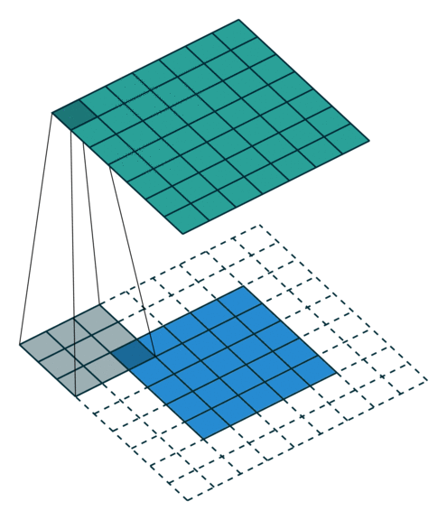

**Режим паддинга** позволяет выбрать значения пикселей, которыми дополняется изображение:

- `zeros` нулями
- `reflect` отражает изображение, относительно граничных пикселей
- `replicate` копирует изображение, после чего отражает и состыковывает с изначальным

**Reflection padding**

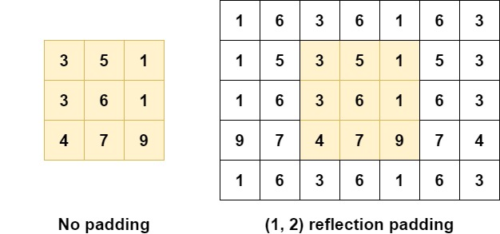

**Replication padding**

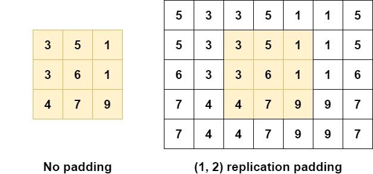

**Dilation**

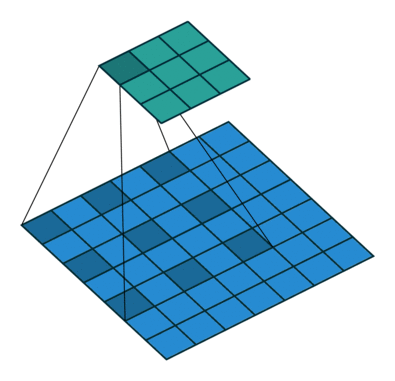

## Пулинговый слой

Для пулинга в PyTorch можно использовать слои, реализованные в модуле `nn`:

- MaxPool2d
- AvgPool2d

Для них тоже можно задавать размер ядра, шаг и паддинг.

Пример использования max pooling с ядром 2х2 и шагом 2

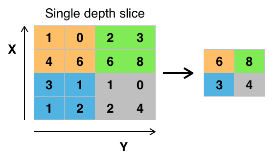